# QMM7301 Case Study 2 [20%]

Bruno Akune (A00331628)

Due: December 10, 2025 at 11:59PM

## **Introduction**

In QMM7300 and QMM7301 all students collected personalized data to analyze. Using RMarkdown to analyze this data, I created this report about study patterns and behaviours.

The relevant variables for this Case Study are:

| Variable | Type |
| --- | --- |
| Date | Identifier |
| Hours Studying | Quantitative |
| Term (F25 or S25.). | Categorical |
| Program (BAPG, CAGC, HAGC) | Categorical |

**Summary Statistics**

This summary statistics is used to compare the amount of time I spend studying to other students and to other students by program.

Summary of the dataset:

[output not shown]

The average study time for each program is the following: BAPG = 3.7 hours CAGC = 4 hours HAGC = 3.3 hour

There is a low difference between all 3 programs but they all study between 3 to 4 hours on average. But, upon analyzing each average, it is safe to conclude that regardless of the program, every analytics program has a study average per day higher than 3.13. 3.13 hours is the average hours a student McGill studies, this means that Cambrian college students are on par with students from other more famous educational institutions

Regarding about my personal study habits, I created a timeline of my study hours throughout the semester:

```
## Time Series:
## Start = 1
## End = 178
## Frequency = 1
##   [1]  8  8  6  3  3  1  6  8  6  6  3  4  1  8  8  6  6  4  3  1  8  8  6  4  2
##  [26]  2  2  6  8  6  3  6  2  2  6  8  5  8  2  5  3  8  6  6  8  4  3  2  8  6
##  [51]  4  8  4  3  4  8  6  6  8  5  5  5  4  6  5  7  2  1  0  6  8  7  2  5  5
##  [76]  3  8  6  3  6  6  8  6  7  8  7  8 10 10 10  7  4  3  8  4  6  6  3  2  2
## [101]  3  5  6  8  6  8  8 10  8  8 10  6 10  2  6  6  5  8  6 10 10  5  6  7  6
## [126]  8  5  6  4  5  4  6  6  4  4  7  7  5  8  5  8  8  5  2  3  8  6  6  6  3
## [151]  3  2  8  2  8  5  3  3  3  8  3  6  6  4  4  4  8  5  4  4  5  8  8  8 10
## [176] 11  9  8
```

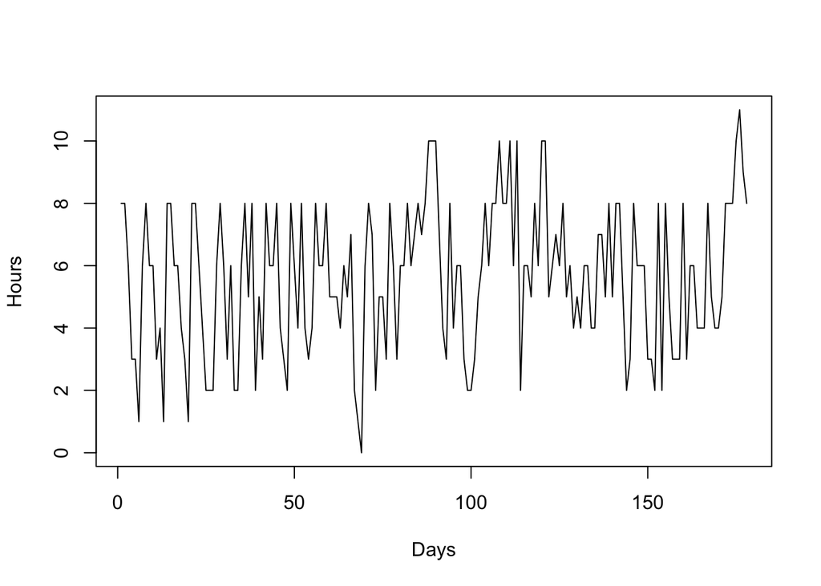

My average study per day has peaks of low and highs study hours. You can identify the low study hour days as I was either having lectures, working or spending it with my hobbies. Additionally, for some few days it has a very high amount of hours studied because of the final exams and projects.

This case study utilizes these 3 methods to analyze students study habits:

- ANOVA
- chi-square tests
- time series analysis

## **Data Analysis**

### Part 1: ANOVA

My hypotheses for this One-way ANOVA is this:

$H_0: \mu_1{BAPG} = \mu_2{CAGC} = \mu_3{HAGC}$

$H_A:$ At least one mean is different

To check whether I reject the Null Hypothesis or not. I will pick 50 random days from each program and conduct the ANOVA analysis

Number of total rows usd for this ANOVA analysis:

```
## [1] 150
```

150 means that I got 50 rows from each program, therefore I can proceed to the analysis.

Using the aov() command, I can do the ANOVA calculation and get a summary table:

```
##              Df Sum Sq Mean Sq F value   Pr(>F)
## Program       2   93.4   46.72   7.269 0.000976 ***
## Residuals   147  944.8    6.43
## ---
## Signif. codes:  0 '***' 0.001 '**' 0.01 '*' 0.05 '.' 0.1 ' ' 1
```

After conducting the one-way anova to tell us that one of the programs has a different mean of studied hours, I can use the Tukey’s HSD method to analyze if there is one program from the 3 programs that has the a different mean.

```
##   Tukey multiple comparisons of means
##     95% family-wise confidence level
##
## Fit: aov(formula = Study ~ Program, data = programs.combined)
##
## $Program
##              diff       lwr        upr     p adj
## CAGC-BAPG -0.2422 -1.442731  0.9583313 0.8819444
## HAGC-BAPG -1.7822 -2.982731 -0.5816687 0.0016864
## HAGC-CAGC -1.5400 -2.740531 -0.3394687 0.0079108
```

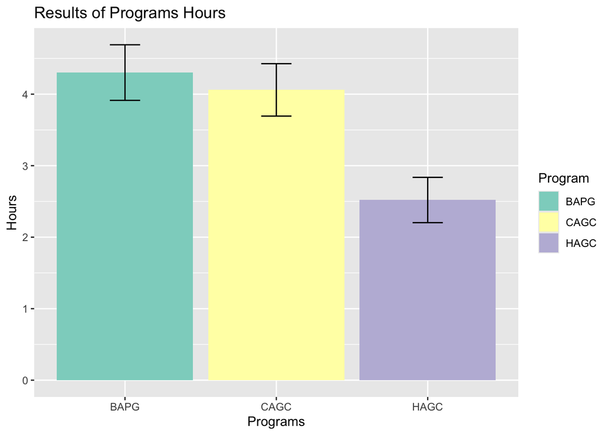

### Part 2: Chi-Square Tests

3.13 hours is the amount of time spent studying per day by students and McGill University and is purportedly the most in Canada. Using this amount as a baseline, I will select 50 days from each program (150 total) and separate them between Above or Below 3.13 hours. This method will analyze whether the distribution of Above and Below days are the same across all programs.

In order to do a Chi Square test we need to verify the following conditions: 1. Counted Data Condition: Count the study hours from each program by separating them into Below and Above days.

2. Independence Assumption: Counts should be independent since randomly allocated. Meaning that the 150 days were randomly selected
3. Randomization Condition: Randomization in packaging that randomly selected the days for this model
4. Expected Cell Frequency/Sample Size Condition: Calculate in R

Based on the four conditions we can use the Chi Square test for Homogeneity Independence to check whether the study pattern differs for each program.

```
##
##         BAPG CAGC HAGC
##   Above   28   33   16
##   Below   22   17   34
```

$H_0:$ The distribution of Above vs Below days is the same for all programs (study-hour category is not related to program)

$H_A:$ The distribution of Above vs Below days is not the same for all programs (study-hour category is related to program)

```
##
##             BAPG     CAGC     HAGC
##   Above 25.66667 25.66667 25.66667
##   Below 24.33333 24.33333 24.33333
```

```
##
##  Pearson's Chi-squared test
##
## data:  observed.hours
## X-squared = 12.222, df = 2, p-value = 0.002218
```

```
##
##               BAPG       CAGC       HAGC
##   Above  0.4605662  1.4474937 -1.9080599
##   Below -0.4730162 -1.4866222  1.9596384
```

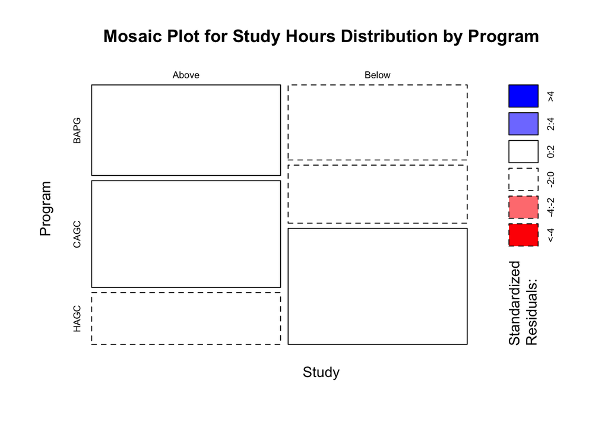

### Part 3: Time Series Analysis

So far, I analyzed the mean of hours studied in a day from each analytics program from Cambrian College, and I categorized their study days into two categories. The first being days that they studied more and less than 3.13 hours, 3.13 hours being the hours a regular McGill student studies. The last part of this case study will be an analysis of my study pattern and predict my study hours.

Amount of days I studied this year(Since I started my program):

```
## [1] 178
```

The following table visualized hte amount hours vs days

```
## p.data.zoo
##  0  1  2  3  4  5  6  7  8  9 10 11
##  1  4 15 20 19 19 40  8 41  1  9  1
```

The first row is the Hours studied and the second row is the amount of days.

Because this data has 2 semester/seasons, it has dasy with almost to no study days. That is because I decided not to study during my brak time and focus into other activities. To avoid any inconsistencies I will find the longest continuous chain of days without a break to conduct my time series analysis.

After finding the longest continuous block, these are the days used in the analysis:

```
## 2025-05-13 2025-05-14 2025-05-15 2025-05-16 2025-05-17 2025-05-18 2025-05-19
##          8          8          6          3          3          1          6
## 2025-05-20 2025-05-21 2025-05-22 2025-05-23 2025-05-24 2025-05-25 2025-05-26
##          8          6          6          3          4          1          8
## 2025-05-27 2025-05-28 2025-05-29 2025-05-30 2025-05-31 2025-06-01 2025-06-02
##          8          6          6          4          3          1          8
## 2025-06-03 2025-06-04 2025-06-05 2025-06-06 2025-06-07 2025-06-08 2025-06-09
##          8          6          4          2          2          2          6
## 2025-06-10 2025-06-11 2025-06-12 2025-06-13 2025-06-14 2025-06-15 2025-06-16
##          8          6          3          6          2          2          6
## 2025-06-17 2025-06-18 2025-06-19 2025-06-20 2025-06-21 2025-06-22 2025-06-23
##          8          5          8          2          5          3          8
## 2025-06-24 2025-06-25 2025-06-26 2025-06-27 2025-06-28 2025-06-29 2025-06-30
##          6          6          8          4          3          2          8
## 2025-07-01 2025-07-02 2025-07-03 2025-07-04 2025-07-05 2025-07-06 2025-07-07
##          6          4          8          4          3          4          8
## 2025-07-08 2025-07-09 2025-07-10 2025-07-11 2025-07-12 2025-07-13 2025-07-14
##          6          6          8          5          5          5          4
## 2025-07-15 2025-07-16 2025-07-17 2025-07-18 2025-07-19 2025-07-20 2025-07-21
##          6          5          7          2          1          0          6
## 2025-07-22 2025-07-23 2025-07-24 2025-07-25 2025-07-26 2025-07-27 2025-07-28
##          8          7          2          5          5          3          8
## 2025-07-29 2025-07-30 2025-07-31 2025-08-01 2025-08-02 2025-08-03 2025-08-04
##          6          3          6          6          8          6          7
## 2025-08-05 2025-08-06 2025-08-07 2025-08-08 2025-08-09 2025-08-10 2025-08-11
##          8          7          8         10         10         10          7
```

Using these dates, I can create. visualiations to start visualizing my study habits

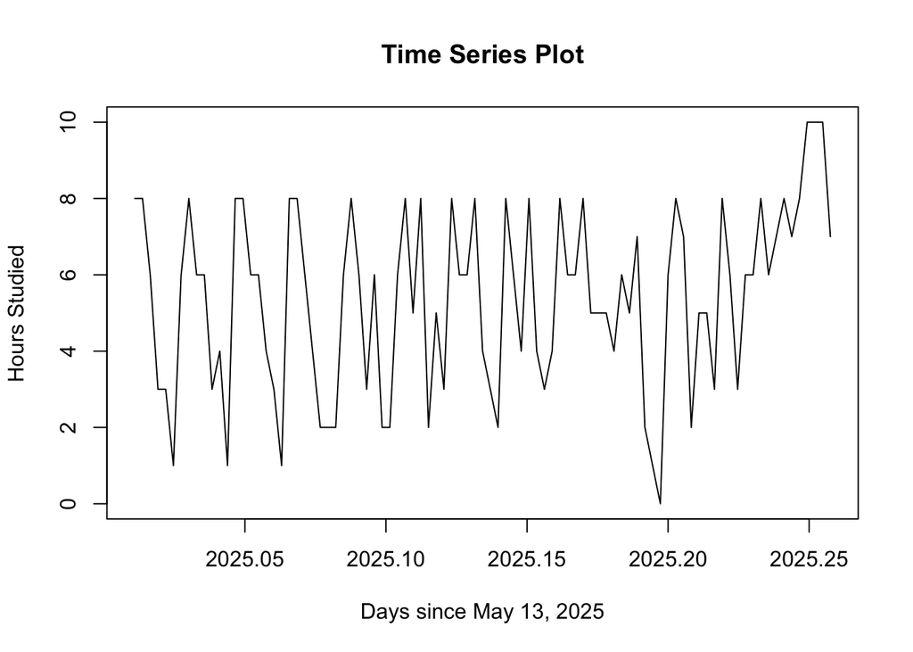

To further analyze it I can decompose the timeline to focus into specific aspects such as trends and seasons.

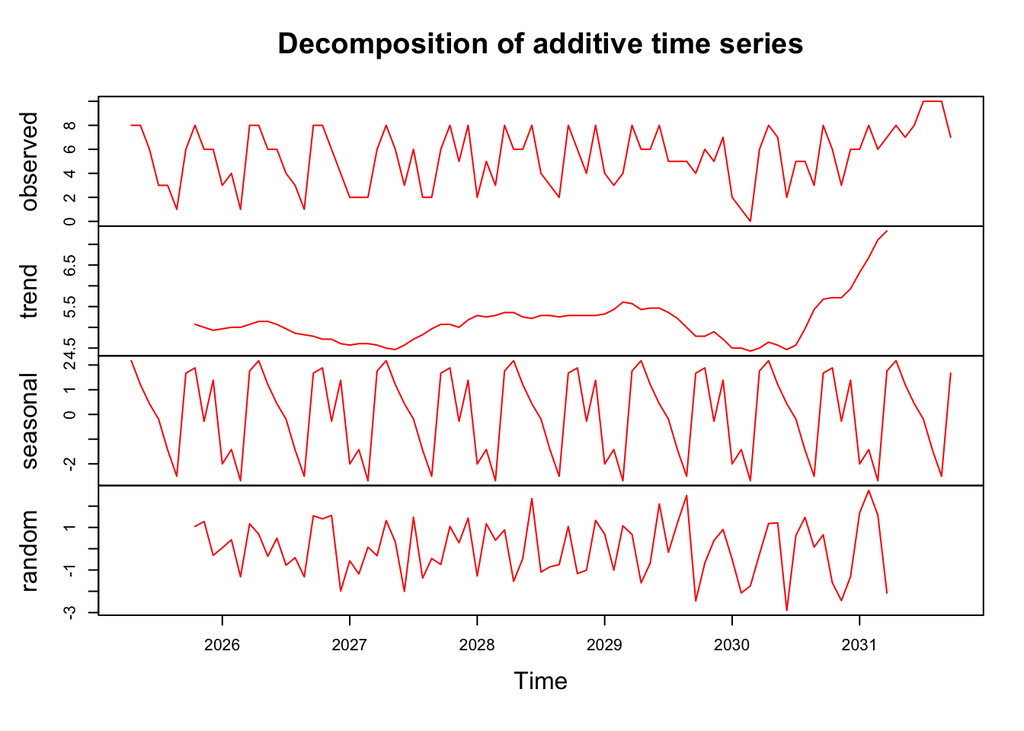

To further analyze the timeline I pick 3 moving averages to find the hours studies. These moving averages are 7, 14 and 30. Essentially they represent the length of one week(7), two weeks(14) and one month(30). The slowest amount will be used for an error forecast. The smaller my L value is, the more ups and downs it will have. While bigger L values will show a more smooth and trend.

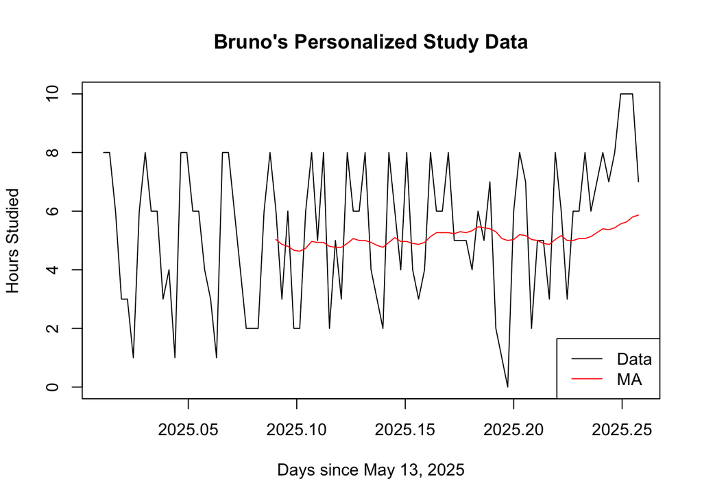

Table with the MSE, MAD and MAPE

```
##           MA7     MA14     MA30
## MSE  4.891156 5.210509 5.402805
## MAD  1.935374 1.976809 1.947541
## MAPE      Inf      Inf      Inf
```

Analyzing the moving averages and identify which one is the best from the 3 models: L = 7

```
##  [1]       NA       NA       NA       NA       NA       NA 5.000000 5.000000
##  [9] 4.714286 4.714286 4.714286 4.857143 4.857143 5.142857 5.142857 5.142857
## [17] 5.142857 5.285714 5.142857 5.142857 5.142857 5.142857 5.142857 4.857143
## [25] 4.571429 4.428571 4.571429 4.285714 4.285714 4.285714 4.142857 4.714286
## [33] 4.714286 4.714286 4.714286 4.714286 4.571429 5.285714 4.714286 5.142857
## [41] 5.285714 5.571429 5.285714 5.428571 5.428571 5.714286 5.428571 5.285714
## [49] 5.285714 5.285714 5.000000 5.000000 5.000000 5.000000 5.285714 5.285714
## [57] 5.285714 5.571429 5.571429 5.714286 6.000000 6.142857 5.571429 5.571429
## [65] 5.428571 5.285714 4.857143 4.285714 4.428571 5.000000 5.142857 4.714286
## [73] 4.428571 4.857143 5.142857 5.428571 5.142857 4.571429 5.142857 5.285714
## [81] 5.714286 6.142857 6.000000 6.285714 6.857143 7.142857 7.714286 8.000000
## [89] 8.571429 8.571429
```

L= 14

```
##  [1]       NA       NA       NA       NA       NA       NA       NA       NA
##  [9]       NA       NA       NA       NA       NA 5.071429 5.071429 4.928571
## [17] 4.928571 5.000000 5.000000 5.000000 5.142857 5.142857 5.142857 5.000000
## [25] 4.928571 4.785714 4.857143 4.714286 4.714286 4.714286 4.500000 4.642857
## [33] 4.571429 4.642857 4.500000 4.500000 4.428571 4.714286 4.714286 4.928571
## [41] 5.000000 5.142857 5.000000 5.000000 5.357143 5.214286 5.285714 5.285714
## [49] 5.428571 5.285714 5.214286 5.214286 5.357143 5.214286 5.285714 5.285714
## [57] 5.285714 5.285714 5.285714 5.357143 5.500000 5.714286 5.428571 5.428571
## [65] 5.500000 5.428571 5.285714 5.142857 5.285714 5.285714 5.357143 5.071429
## [73] 4.857143 4.857143 4.714286 4.928571 5.071429 4.857143 4.928571 4.857143
## [81] 5.285714 5.642857 5.714286 5.714286 5.714286 6.142857 6.500000 6.857143
## [89] 7.357143 7.285714
```

L = 30

```
##  [1]       NA       NA       NA       NA       NA       NA       NA       NA
##  [9]       NA       NA       NA       NA       NA       NA       NA       NA
## [17]       NA       NA       NA       NA       NA       NA       NA       NA
## [25]       NA       NA       NA       NA       NA 5.033333 4.866667 4.800000
## [33] 4.666667 4.633333 4.733333 4.966667 4.933333 4.933333 4.800000 4.766667
## [41] 4.766667 4.900000 5.066667 5.000000 5.000000 4.933333 4.833333 4.766667
## [49] 4.933333 5.100000 4.966667 4.966667 4.900000 4.866667 4.933333 5.133333
## [57] 5.266667 5.266667 5.266667 5.233333 5.300000 5.266667 5.333333 5.466667
## [65] 5.433333 5.400000 5.300000 5.066667 5.200000 5.300000 5.433333 5.233333
## [73] 5.200000 5.166667 5.000000 5.133333 5.233333 5.266667 5.200000 5.200000
## [81] 5.333333 5.266667 5.366667 5.533333 5.633333 5.633333 5.766667 5.900000
## [89] 5.966667 6.033333
```

Table with all 3

```
##            MA7     MA14     MA30
##  [1,]       NA       NA       NA
##  [2,]       NA       NA       NA
##  [3,]       NA       NA       NA
##  [4,]       NA       NA       NA
##  [5,]       NA       NA       NA
##  [6,]       NA       NA       NA
##  [7,] 5.000000       NA       NA
##  [8,] 5.000000       NA       NA
##  [9,] 4.714286       NA       NA
## [10,] 4.714286       NA       NA
## [11,] 4.714286       NA       NA
## [12,] 4.857143       NA       NA
## [13,] 4.857143       NA       NA
## [14,] 5.142857 5.071429       NA
```

[output cut: 76 more lines]

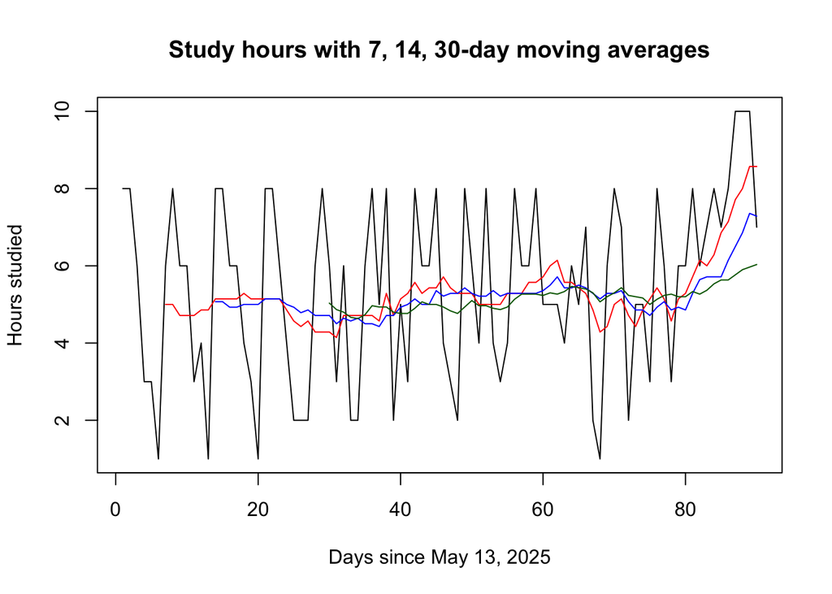

Forecasting the next 5 days

Simple Exponential Smoothing:No seasonality and no trend

Holt (Double) Exponential Smoothing:Has a trend but no seasonality

Holt‑Winters (Triple) Exponential Smoothing:Has a trend and a seasonality

For my study data I will be using the Holt (Double) Exponential Smoothing, because from previous visualizations it does not have a seasonality, but it has a trend going upwards.

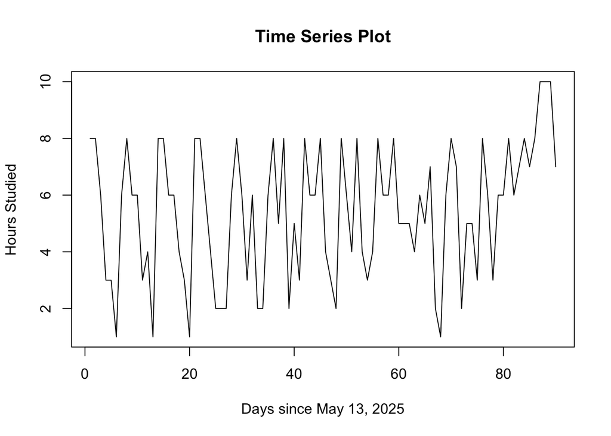

Using the Holt (Double) Exponential Smoothing we can forecast what the results will be in the next 5 days.

```
## Holt-Winters exponential smoothing with trend and without seasonal component.
##
## Call:
## HoltWinters(x = p.data.ts, gamma = FALSE)
##
## Smoothing parameters:
##  alpha: 0.1748471
##  beta : 0
##  gamma: FALSE
##
## Coefficients:
##     [,1]
## a 7.9605
## b 0.0000
```

```
##     alpha
## 0.1748471
```

```
## beta
##    0
```

```
##    Point Forecast    Lo 80    Hi 80    Lo 95    Hi 95
## 91         7.9605 4.891447 11.02955 3.266788 12.65421
## 92         7.9605 4.844887 11.07611 3.195581 12.72542
## 93         7.9605 4.799013 11.12199 3.125423 12.79558
## 94         7.9605 4.753795 11.16720 3.056268 12.86473
## 95         7.9605 4.709206 11.21179 2.988075 12.93292
```

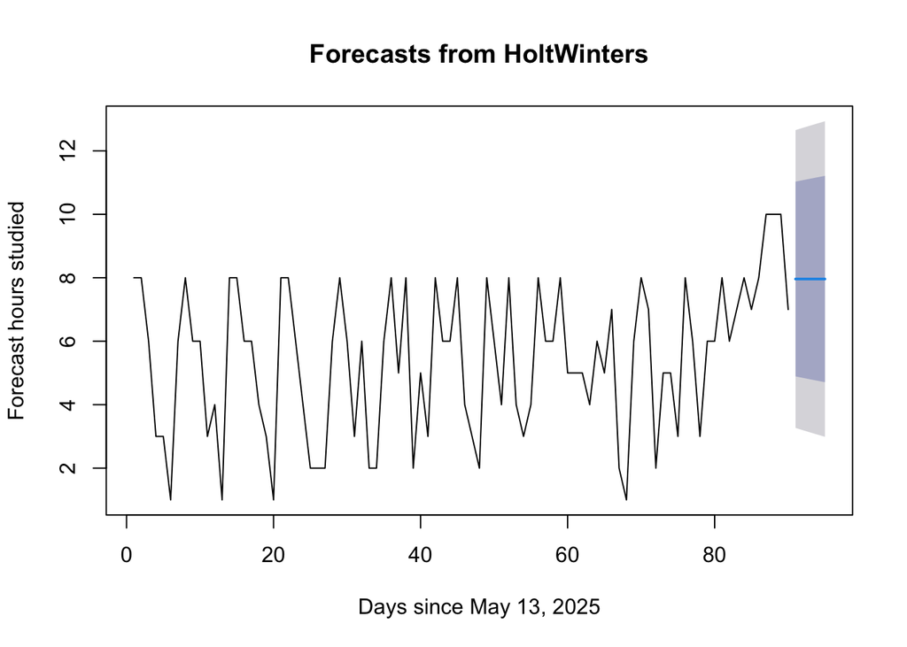

The overall conclusion is that even if my study hours has a upwards trend, it wasn’t relevant enough to consider using the Holt (Double) Exponential Smoothing. Therefore if considered as if I used the Simple Exponential Smoothing.

The outcome is that it will predict I will study another 8 hours for the next 5 days, with the gray bands being th uncertainities.

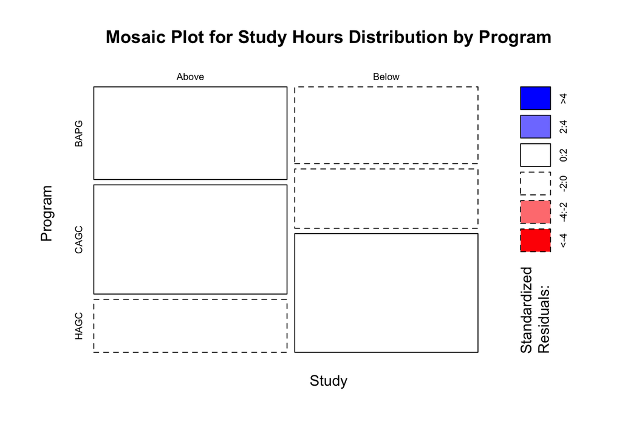